# Carnegie SEM

Paul Harmon and Sarah McKnight

November 1, 2017

## The Carnegie Classifications

- Based on PCA on correlation matrix of ranked institutional data
- Two Scales: Aggregate (x-axis) and Per-Capita (y-axis) _ Three categories of PhD-granting institutions: R1 to R3

## Carnegie in 2015

[figure not shown]

The 2015 Classifications

## How are Scores Calculated?

The Carnegie Classifications are based on ranked data (because some schools are vastly larger on certain metrics than the rest). The ranked data are partitioned into two datasets and a PCA is generated on the both datasets. The first PC score is then used as an index for each trait.

## Aggregate and Per-Capita Indices

The classifications are calculated based on two indices of institutional output. The first is based on a weighted average of the number of PhDs awarded by the institution; the second is based on a per-capita measurement of research expenditures and research staff. **Aggregate Index:**
$$Ag.Index_{i} = HumanitiesPhD_{i} + StemPhD_{i} + SocialSciencePhD_{i}$$
$$+ OtherPhD_{i} + StemExpenditures_{i} + NonStemExpenditures_{i} + ResearchStaff_{i}$$
**Per Capita Index:**
$$PC.Index_{i} = \frac{ResearchStaff_{i} + StemExpenditures_{i} + NonStemExpenditures_{i}}{FacultySize_{i}}$$

## PCA Plot - Arbitrary Boundaries

From here, the methodology of the Carnegie Classifications is to produce a plot of the two correlated indices. Lines are arbitrarily drawn to create three partitions of the space. The following plot is produced.

## Problems with PCA

Many of the decisions made in this process are data driven and are outside the control of researchers:

- Aggregate and Per-Capita Indices were constructed so that they are correlated, but how correlated they are can change from year to year
- Attributes of the PCAs themselves change from year to year, meaning important policy drivers in one year might not be important in the next year (Social Science PhDs)
- This can affect policy decisions made based on the classifications
- Data are rarely grouped into three neat clusters, and lines are arbitrarily drawn
- Both PCAs throw out roughly 30 percent of the variation in underlying variables

[figure not shown]

**Because of this, we wanted to try fitting a Structural Equation Model to create an index to compete with the Carnegie Classifications**

## Structural Equation Models

**GoaL**: Model two latent traits, one for the **aggreagate scale** and the other for the **per-capita scale**, and then use those to generate a “super-latent” single trait.

We could then separate institutions into groups via univariate model-based clustering or something as simple as breaking the single variable into several groups.

## Problems Solved by the SEM

The SEM is constructed a priori because we set the latent variables and correlation structure beforehand. This leads to a solution that is less succeptible to change when the data are updated.

- We don’t have an arbitray curve slicing up groups of schools - it’s either cut based on a model-based clustering algorithm or sliced into proportional groups.

## SEM Model

```
## lavaan (0.5-23.1097) converged normally after 499 iterations
##
##   Number of observations                           276
##
##   Estimator                                         ML
##   Minimum Function Test Statistic              253.377
##   Degrees of freedom                                24
##   P-value (Chi-square)                           0.000
##
## Model test baseline model:
##
##   Minimum Function Test Statistic             4294.889
##   Degrees of freedom                                45
##   P-value                                        0.000
##
## User model versus baseline model:
##
##   Comparative Fit Index (CFI)                    0.946
##   Tucker-Lewis Index (TLI)                       0.899
##
## Loglikelihood and Information Criteria:
##
##   Loglikelihood user model (H0)             -14094.561
##   Loglikelihood unrestricted model (H1)     -13967.873
##
##   Number of free parameters                         41
##   Akaike (AIC)                               28271.122
##   Bayesian (BIC)                             28419.558
##   Sample-size adjusted Bayesian (BIC)        28289.554
##
## Root Mean Square Error of Approximation:
##
##   RMSEA                                          0.186
##   90 Percent Confidence Interval          0.166  0.207
##   P-value RMSEA <= 0.05                          0.000
##
## Standardized Root Mean Square Residual:
##
##   SRMR                                           0.077
##
```

[output cut: 59 more lines]

```
## Variances:
##                    Estimate  Std.Err  z-value  P(>|z|)
##    .HUM_RSD        5338.783  451.679   11.820    0.000
##    .OTHER_RSD      5164.306  357.474   14.447    0.000
##    .SOCSC_RSD      3705.418  367.210   10.091    0.000
##    .STEM_RSD        733.950  117.594    6.241    0.000
##    .PDNFRSTAFF      762.543  172.466    4.421    0.000
##    .S.ER.D          290.562   94.904    3.062    0.002
##    .NONS.ER.D      3302.698  295.529   11.176    0.000
##    .PDNRSTAFF_PC    546.562  238.753    2.289    0.022
##    .S.ER.D_PC       539.453  267.554    2.016    0.044
##    .NONS.ER.D_PC   5708.965  395.986   14.417    0.000
##     Aggregate         1.000
##     PerCap            1.000
##     Overall           1.000
```

```
##
##       A  B  C
##   15  3 48 64
##   16 39 60  8
##   17 46  6  2
```

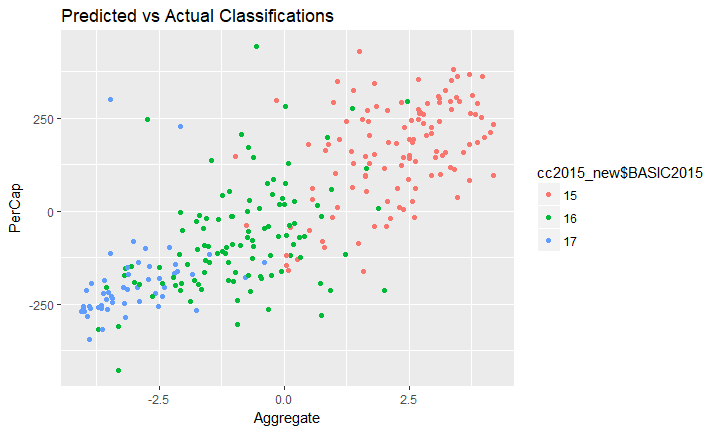

Plot of the SEM latent traits

## Path Diagram

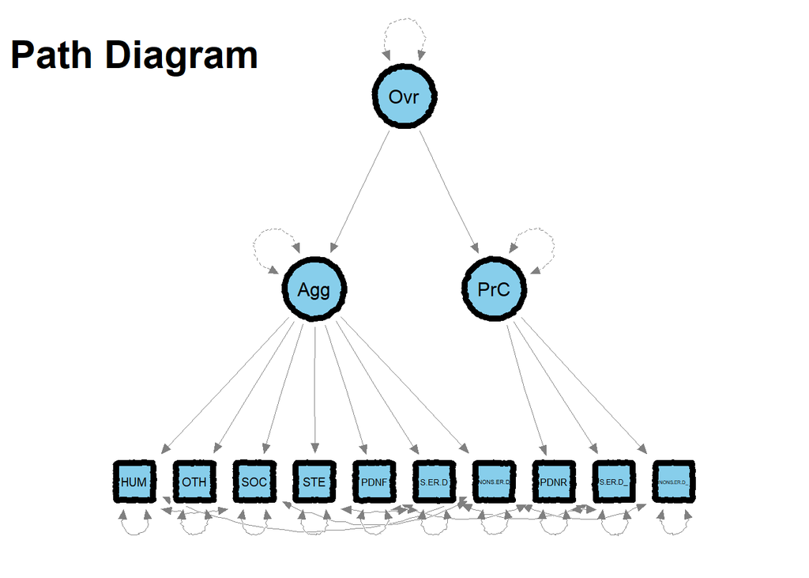

## Densities of Our Scores

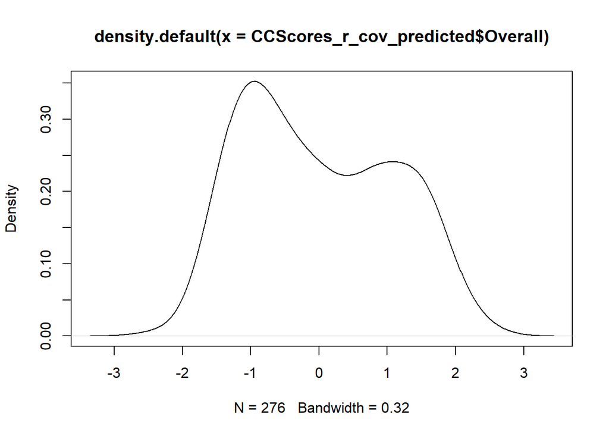

## PCA vs. SEM

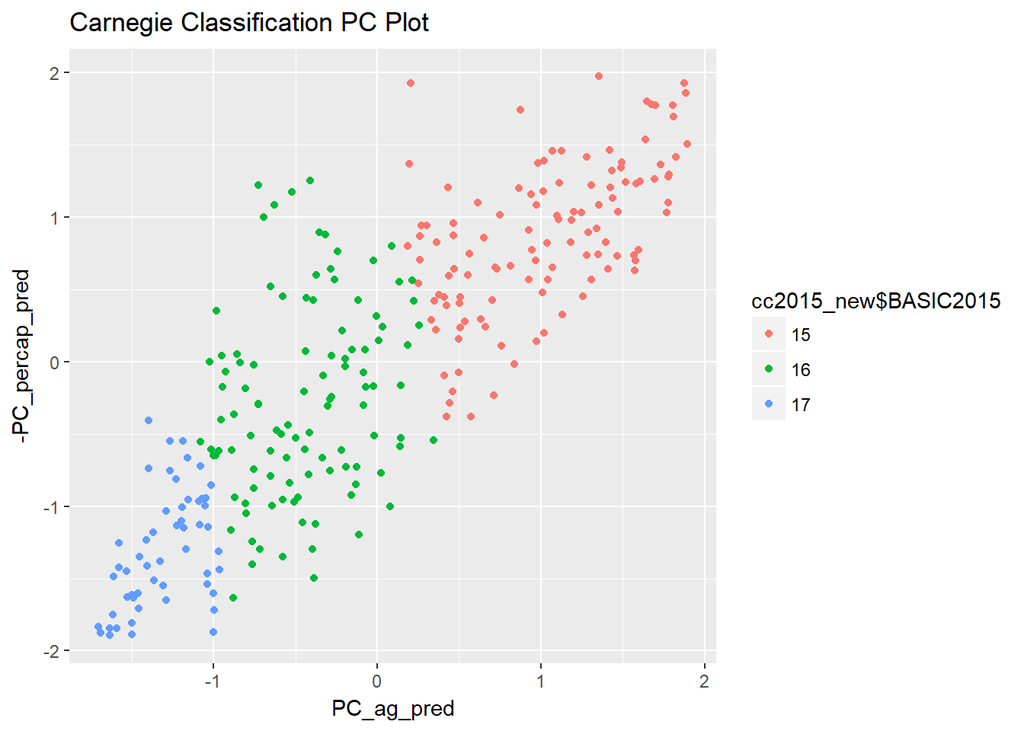

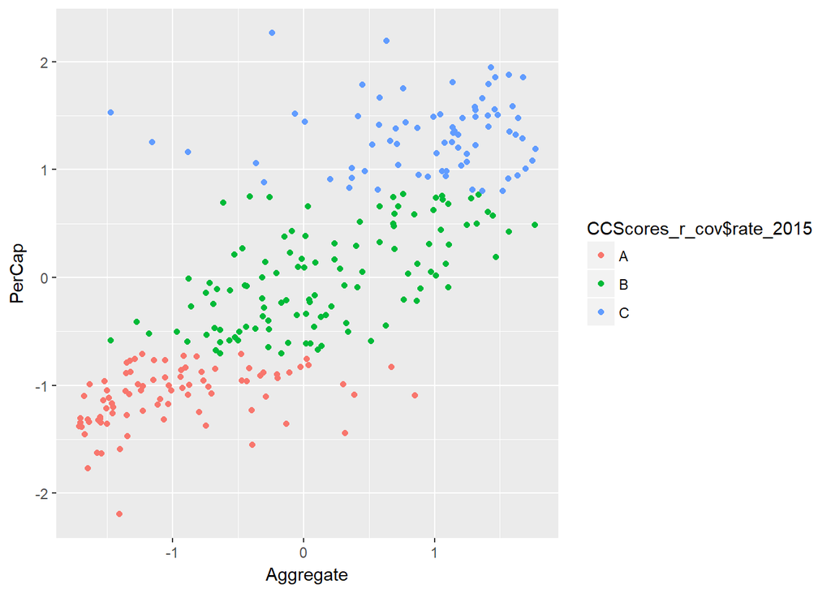

```
##                                    Aggregate     PerCap PC_ag_pred
## Villanova University              -1.0945852 -1.1310469 -1.0833675
## Georgetown University              0.4683491  0.9822118  0.4637039
## Howard University                 -0.2025852 -0.9015565 -0.1580017
## University of Colorado Boulder     1.1371085  1.3905484  1.1264385
## Montclair State University        -1.4586452 -1.2625550 -1.4535582
## University of San Diego           -1.4560552 -1.2000747 -1.3670688
## University of Iowa                 1.2451849  0.4859647  1.3079997
## University of Notre Dame           0.6856202  0.7448668  0.6514406
## Tulane University of Louisiana     0.3511621  0.8289685  0.3040076
## Washington University in St Louis  1.1515140  1.3566463  1.0705777
##                                   PC_percap_pred   Distance
## Villanova University                   1.1284557 0.01151306
## Georgetown University                 -0.9574457 0.02519796
## Howard University                      0.9256706 0.05068709
## University of Colorado Boulder        -1.4569260 0.06722976
## Montclair State University             1.3512499 0.08884071
## University of San Diego                1.1815082 0.09090274
## University of Iowa                    -0.5659278 0.10168474
## University of Notre Dame              -0.8578906 0.11807890
## Tulane University of Louisiana        -0.9408351 0.12139888
## Washington University in St Louis     -1.4560939 0.12822060
```

```
##                                                     Aggregate     PerCap
## CUNY Graduate School and University Center         -0.4097210  0.7526063
## University of Vermont                               0.3162084 -1.4417980
## Teachers College at Columbia University            -1.5747433 -1.6250458
## California Institute of Technology                  0.9905447  0.6259356
## Clarkson University                                -0.8805412  1.1647646
## Wake Forest University                              0.8512582 -1.0922770
## Clark Atlanta University                           -1.1543860  1.2530465
## SUNY College of Environmental Science and Forestry -1.4721709  1.5304477
## Claremont Graduate University                      -1.4069690 -2.1943214
## University of Colorado Denver                       1.0441518  1.5094094
##                                                    PC_ag_pred
## CUNY Graduate School and University Center          0.4100551
## University of Vermont                              -0.4967369
## Teachers College at Columbia University            -0.6500598
## California Institute of Technology                  0.2031184
## Clarkson University                                -1.2685255
## Wake Forest University                             -0.7252286
## Clark Atlanta University                           -0.9865385
## SUNY College of Environmental Science and Forestry -1.3954723
## Claremont Graduate University                      -0.4168306
## University of Colorado Denver                      -0.2209300
##                                                    PC_percap_pred Distance
## CUNY Graduate School and University Center             0.09658196 1.180319
## University of Vermont                                  0.52601109 1.224559
## Teachers College at Columbia University                0.61680024 1.368064
## California Institute of Technology                    -1.92687466 1.520685
## Clarkson University                                    0.54924653 1.757375
## Wake Forest University                                 0.29323889 1.767420
## Clark Atlanta University                               0.64766475 1.908108
## SUNY College of Environmental Science and Forestry     0.40819118 1.940156
## Claremont Graduate University                          0.49158967 1.969688
## University of Colorado Denver                          0.61351726 2.471285
```

```
##    Min. 1st Qu.  Median    Mean 3rd Qu.    Max.
## 0.01151 0.32796 0.46604 0.52895 0.65814 2.47128
```

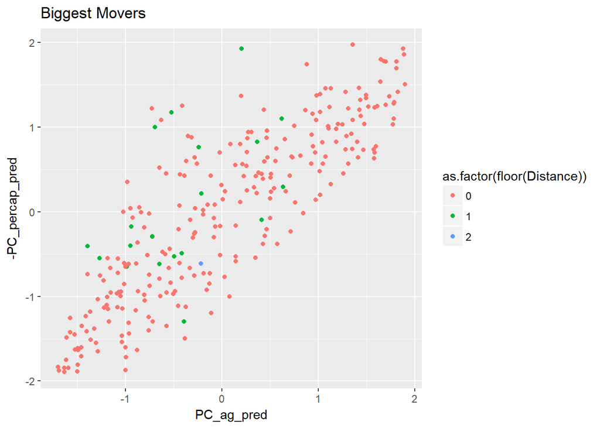

## Questions For Laura

- What is the official term for “super latent trait”?
- Could we improve the fit by doing something other than just modeling covariances?
- Comparing scores from PCA to SEM - is this reasonable?